# **2020 Manifesto Text Analysis**

Jewel Bansah

2/8/2022

Hi everyone !

In this session, i perform text analysis on the 2020 manifesto’s of the two dominant political parties in my country, Ghana.

These are the

- New Patriotic Party - NPP
- National Democratic Congress - NDC

[figure not shown]

Image 1

By using the tidytext package(Silge and Robinson 2016) and other tidy tools in R, i attempt to apply tidy principles to text mining.

The goal is to practice my NLP skills and at the same time discover interesting patterns & insights these documents may hold.

Lets go!!!

## **SETTING UP ENVIRONMENT**

```r
library(tidyverse)
library(tidytext)
library(tm)
library(quanteda)
```

```r
library(wordcloud)
library(ggrepel)
```

## **IMPORTING DOCUMENTS & PRE-PROCESSING**

```r
## NPP

npp_2020 <- read_lines("NPP 2020 Final.txt") # Import NPP manifesto
npp_tidy <- tibble(text = npp_2020) # Converting to dataframe

# NDC
ndc_2020 <- read_lines("NDC 2020 Final.txt") # Import NDC Manifesto
ndc_tidy <- tibble(text = ndc_2020) # Converting to a data frame

#Tokenization

ndc_token <- ndc_tidy %>% unnest_tokens(word,text) %>%
  anti_join(stop_words) %>% filter(!str_detect(word,"[0-9]+"))
npp_token <-  npp_tidy %>% unnest_tokens(word,text) %>%
  anti_join(stop_words) %>% filter(!str_detect(word,"[0-9]+"))
```

## **COMBINING BOTH DOCUMENTS**

Joining the two tidy manifestos

```r
manifesto_2020 <- bind_rows(mutate(ndc_token, party = "NDC"),
                       mutate(npp_token, party = "NPP")) %>% mutate(linenumber = row_number()) %>%
  relocate(linenumber, .before = word)

manifesto_2020
```

```
## # A tibble: 17,256 × 3
##    linenumber word      party
##         <int> <chr>     <chr>
##  1          1 people’s  NDC
##  2          2 manifesto NDC
##  3          3 people’s  NDC
##  4          4 manifesto NDC
##  5          5 people’s  NDC
##  6          6 manifesto NDC
##  7          7 people’s  NDC
##  8          8 manifesto NDC
##  9          9 contents  NDC
## 10         10 acronyms  NDC
## # … with 17,246 more rows
```

```r
# Most popular words used in the manifesto

manifesto_2020 %>% count(word, sort = TRUE)
```

```
## # A tibble: 4,146 × 2
##    word            n
##    <chr>       <int>
##  1 government    190
##  2 ghana         179
##  3 manifesto     154
##  4 development   151
##  5 ndc           149
##  6 sector        143
##  7 national      116
##  8 party         108
##  9 health        105
## 10 patriotic      94
## # … with 4,136 more rows
```

## **IDENTIFYING WORDS UNIQUE TO EACH MANIFESTO**

By using term frequency_Inverse document frequency (tf-idf) and wordcloud

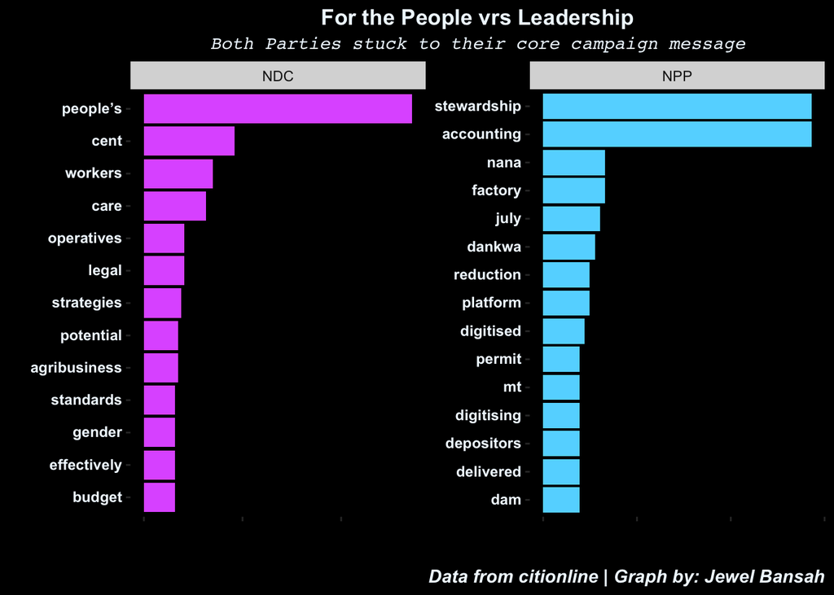

```r
# Run a tf-idf to see the words unique to each party

manifesto_idf <- manifesto_2020 %>% count(word,party) %>%
  bind_tf_idf(word,party,n) %>% arrange(desc(tf_idf))

# Plot of top 15 words unique to each party

manifesto_idf %>% mutate(word = as.factor(word)) %>%
  group_by(party) %>%
  slice_max(tf_idf, n = 10) %>%
  ungroup() %>%
  mutate(word = reorder(word, tf_idf)) %>%
  ggplot(aes(tf_idf,word, fill = party)) +
  geom_col()+
  scale_fill_manual(values = c("#E063FF", "#63D8FF")) +
  facet_wrap(~party, scales = "free") +
  theme (plot.caption = element_text(size = 13,
    face = "bold.italic", colour = "aliceblue"),
    panel.grid.major = element_line(linetype = "blank"),
    panel.grid.minor = element_line(linetype = "blank"),
    axis.text = element_text(size = 13, face = "bold",
        colour = NA), axis.text.y = element_text(colour = "antiquewhite"),
    legend.title = element_text(face = "bold"),
    panel.background = element_rect(fill = "gray0"),
    plot.background = element_rect(fill = "gray0",
        colour = NA), legend.position = "none") +
  labs(caption = "Data from citionline | Graph by: Jewel Bansah") + theme(plot.subtitle = element_text(family = "mono",
    size = 12, colour = "darkseagreen1"),
    axis.text = element_text(hjust = 0.4,
        vjust = 0.4)) +labs(subtitle = "The NDC had more words centered around the people as their Manifesto title suggested") + theme(plot.caption = element_text(size = 11),
    panel.grid.major = element_line(colour = NA),
    panel.grid.minor = element_line(colour = NA),
    axis.text = element_text(size = 11)) +labs(subtitle = "The NDC had more words centered around the people,/n the NPP focused on the economy") + theme(axis.text = element_text(size = 9),
    axis.text.y = element_text(colour = "aliceblue")) + theme(plot.subtitle = element_text(size = 11,
    face = "italic", colour = "aliceblue",
    hjust = 0.5), plot.title = element_text(face = "bold",
    colour = "aliceblue", hjust = 0.5)) +labs(title = "For the People vrs Leadership",
    subtitle = "Both Parties stuck to their core campaign message")
```

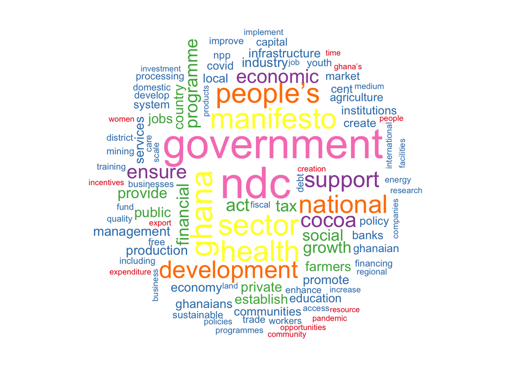

```r
# Wordcloud

# NDC
manifesto_2020 %>% filter(party == "NDC") %>%
  count(word) %>%
  with(wordcloud(word,n,max.words = 100,scale = c(3.6,.25),colors = brewer.pal(8, "Set1"),
                 random.order = FALSE))
```

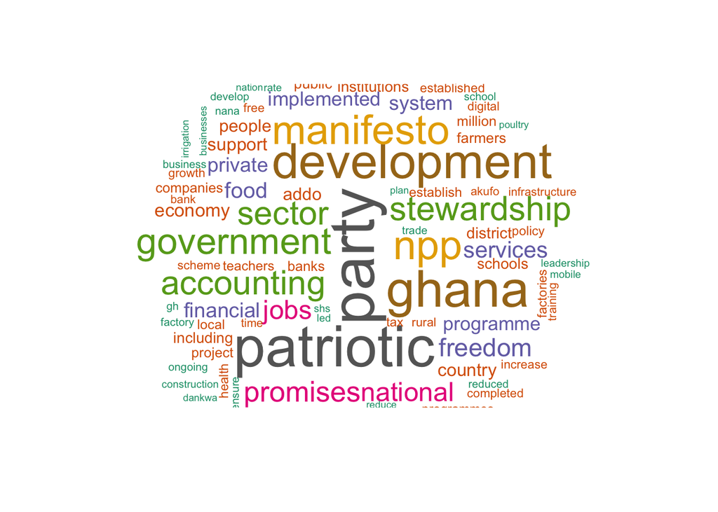

```r
# NPP

manifesto_2020 %>% filter(party == "NPP") %>%
  count(word) %>%
  with(wordcloud(word,n,max.words = 100,scale = c(3.6,.25),colors = brewer.pal(8, "Dark2"),
                 random.order = FALSE))
```

## **SENTIMENT ANALYSIS**

Gauging the mood (negative & positive) of both manifestos

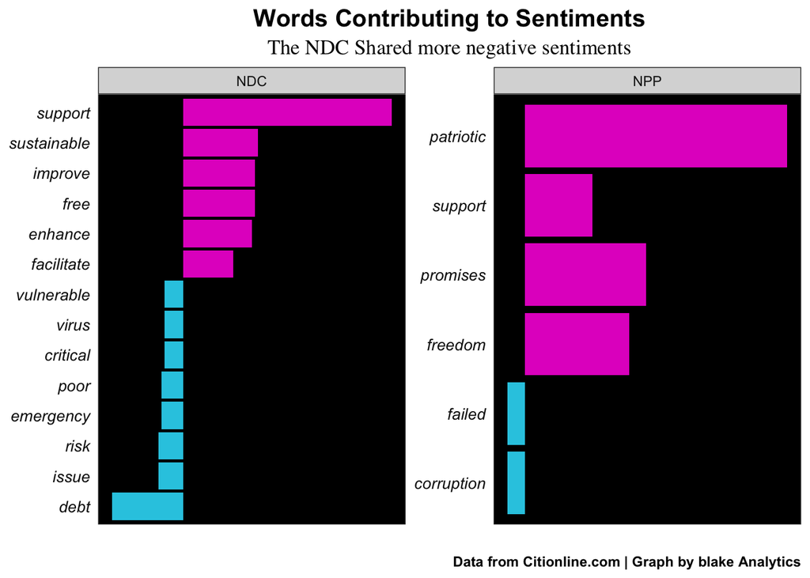

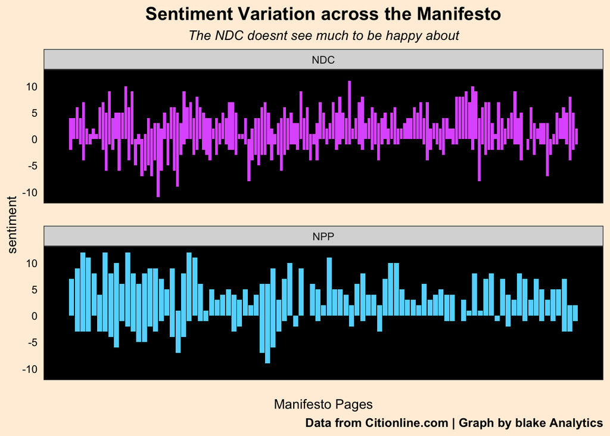

## **SIMILAR WORDS USED IN BOTH MANIFESTOS**

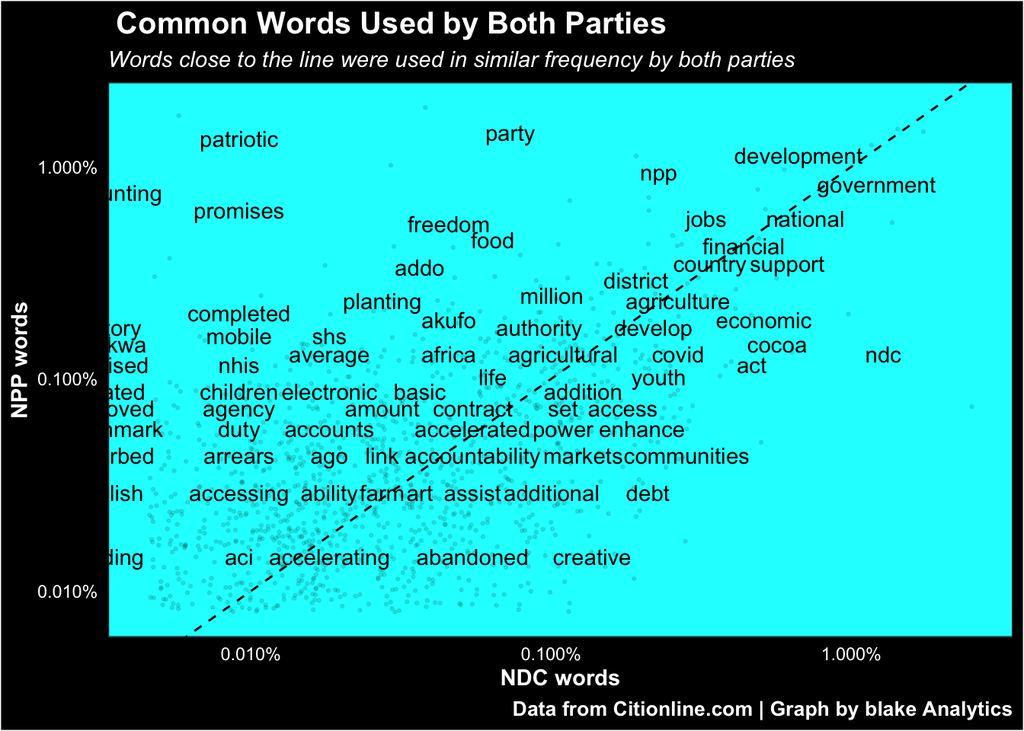

```r
# Relationship between Manifesto's

manifesto_2020 %>%
  count(party,word) %>%
  group_by(party) %>%
  mutate(proportion = n/sum(n)) %>%
  ungroup() %>%
  select(-n) %>%
  pivot_wider(names_from = party,values_from = proportion, values_fill = 0) %>%
  ggplot(aes(NDC,NPP)) +
  geom_abline(color = "black", lty = 2) +
  geom_jitter(alpha = 0.1, size = 0.5, width = 0.3, height = 0.3) +
  geom_text(aes(label = word), check_overlap = TRUE, vjust = 1.0) +
  scale_x_log10(labels =scales::percent) +
  scale_y_log10(labels = scales::percent) +
  scale_color_gradient(limits = c(0, 0.001),
                       low = "darkslategray4", high = "gray75") +
  theme(legend.position="none")+
  labs(title = " ",subtitle = "Words close to the line were used in similar frequency by both parties",
       x = "NDC words", y = "NPP words")+
  theme_bw() + theme(plot.subtitle = element_text(size = 11,
    face = "italic", colour = "white"), plot.caption = element_text(size = 10,
    face = "bold", colour = "white"), axis.ticks = element_line(linetype = "blank"),
    panel.grid.major = element_line(linetype = "blank"),
    panel.grid.minor = element_line(size = 1.1,
        linetype = "blank"), axis.title = element_text(face = "bold",
        colour = "white"), axis.text.x = element_text(colour = "white"),
    axis.text.y = element_text(colour = "white"),
    plot.title = element_text(size = 15,
        face = "bold", colour = "white"),
    panel.background = element_rect(fill = "cyan"),
    plot.background = element_rect(fill = "black")) +labs(title = " Common Words Used by Both Parties",
    caption = "Data from Citionline.com | Graph by blake Analytics")
```

## **SUMMARY**

Coming into the 2020 elections in Ghana, the ruling NPP was hoping to win a second term while the opposition party, the NDC was looking to topple them democratically.

Sentiment analysis shows the NDC has more negative sentiments throughout their manifesto compared to the NPP. Again this is expected because the NDC is in opposition and would more likely focus on pointing out the short comings of the current government. The NPP on the other hand will look to focus more on their achievement and promises of a better or more positive future.

Going into the elections, the most poular subjects were jobs, Covid and the financial sector cleanup amongst others. It is therefore not surprising to see these and other related words by used by both parties at similar frequencies.

Below is the link to both Manifestos

[NPP - Leadership In Service](https://drive.google.com/file/d/1PDB3eraA_nYjSVUbb5tiJp7DGYmrQm3O/view)

[NDC - The People’s Manifesto](https://drive.google.com/file/d/1TvacMm1sGVAIoaiYDmM-TiMPu2J14KH7/view)

`SessionInfo()`